# filter

## What does the order of a filter do?

One of the essential steps in signal processing is getting rid of unwanted noise from the signal. A signal could be composed of multiple frequency components. Real-life signal (signals from audio, video etc.) consists of various frequencies.

This notebook would demonstrate signal denoising. First, I will take a clean signal consisting of only one frequency component. I will add noise to it. I will then filter the signal by removing unwanted frequencies.

Our noiseless signal contains only one frequency component, i.e. 50 Hz. We add noise to the clean signal by adding two additional frequency components, one of 70 Hz and 150 Hz.

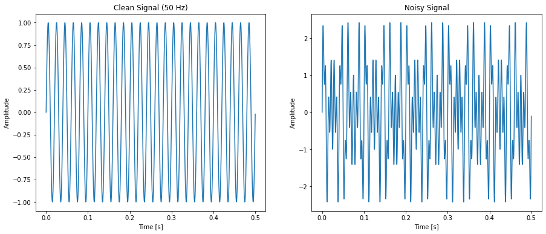

Our objective is to eliminate the noise from the noisy signal and restore it to the original (Clean) signal. We will first investigate what frequency components are present in the noisy signal.

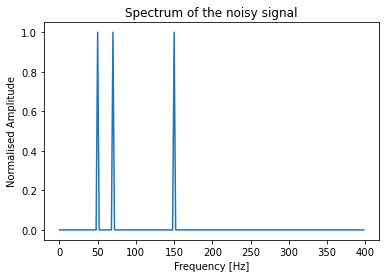

In the plot above, we observe that the noisy signal consists of 50 Hz, 70 Hz and 150 Hz. Now, our objective is to design a filter to get rid of any frequency components other than 50 Hz (the frequency of the clean signal)

I designed an FIR (Butterworth Low Pass) filter (Using Python packages) to filter out unwanted noise components. I choose FIR over IIR because the hardware realisation of FIR is easier compared to IIR.

Our cutoff frequency will be little more then 50 Hz to take care of the transition width between passband and stopband. I have set it to 55 Hz.

Let us try to retreive the original clean signal with a filter of order 1

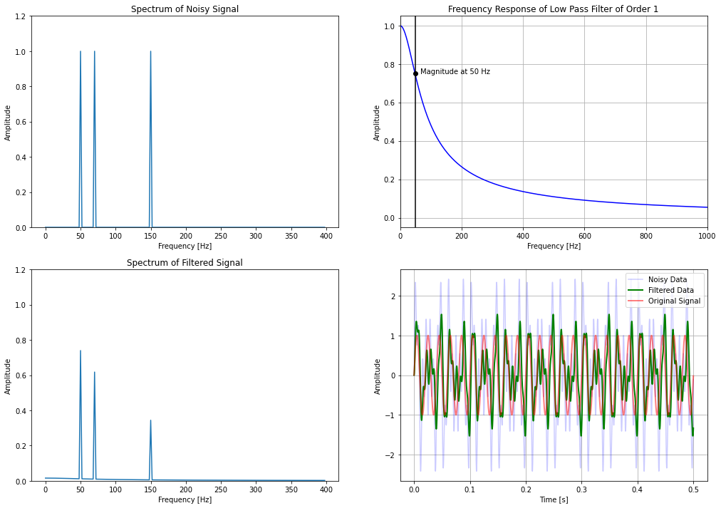

The frequency response of the filter is far from idle. As we can see in the top right plot, frequencies beyond 50 Hz will still appear in the signal, although with lower amplitude. Consequently, the filtered signal in the bottom right plot hardly looks like the original signal. Also, observe the black dot in the top right plot. It shows the magnitude at 50 Hz and the same magnitude is observed in the frequency response of the filtered signal (bottom left plot)

To improve the frequency response, we will need to increase the order of the filter.

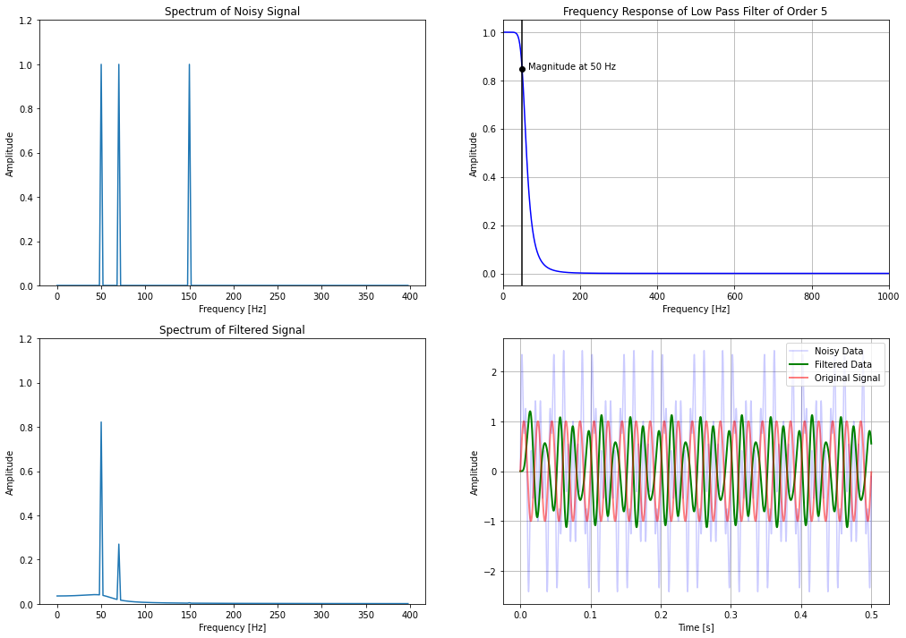

The frequency response with an order 5 filter is better relative to order 1. The frequency response at 150 Hz is almost 0. But we still have a significant amplitude at the frequency of 70 Hz. We will again increase the order and try to minimize the magnitude of 70 Hz component.

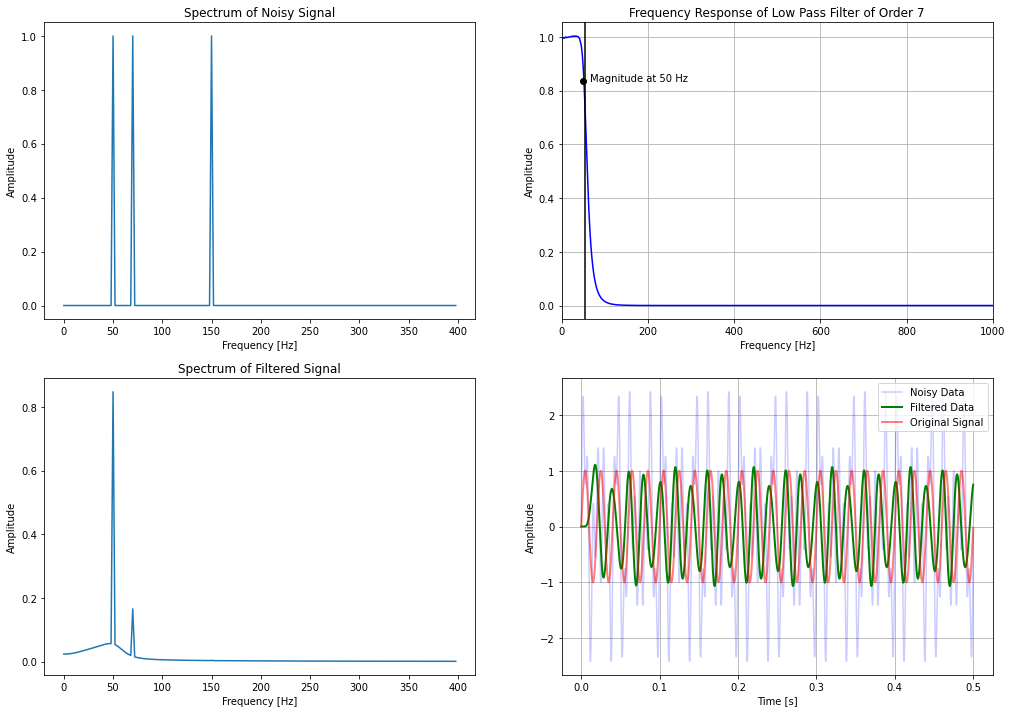

With an order 7 filter, the magnitude of frequency at 70 Hz is much lower compared to the fundamental frequency of 50 Hz.

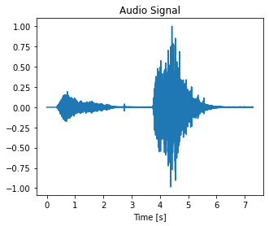

Below, we can hear the raw signal as recorded by a smartphone microphone

[interactive chart not shown]

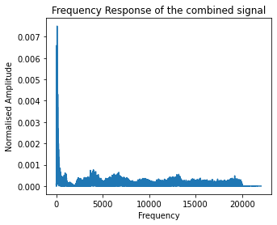

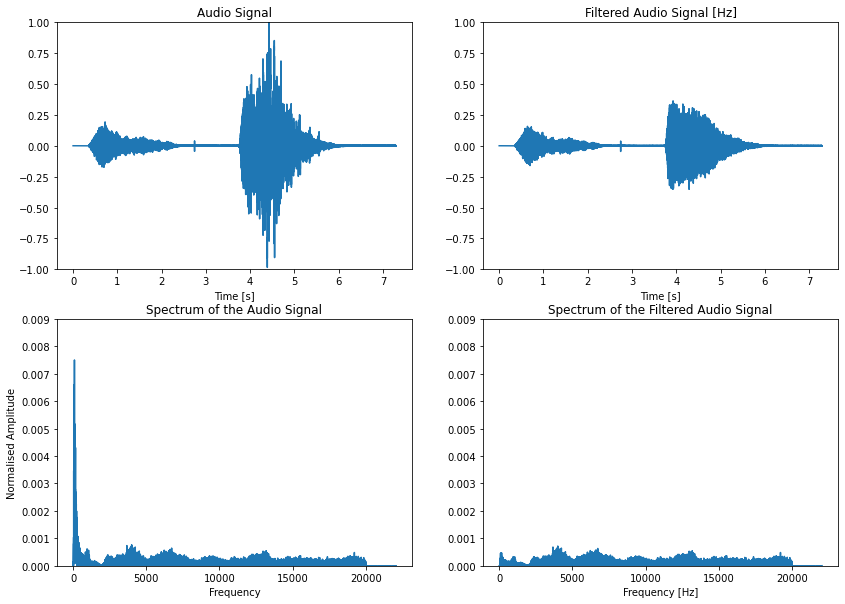

Listen to the audio signal filtered using order 1 filter.

[interactive chart not shown]

Now we try with order 5

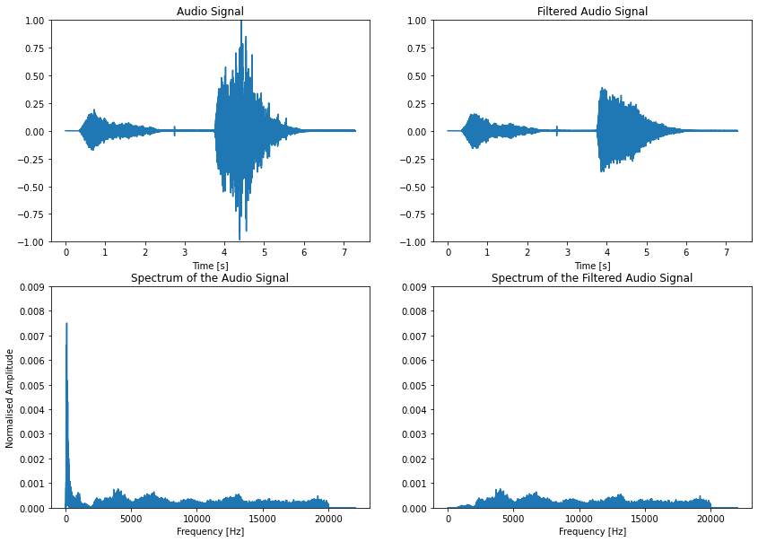

Listen to the audio signal filtered using order 5 filter.

[interactive chart not shown]

**Conclusion**  
We observed that as the order of a filter increases, the steepness of the transfer characteristics from the stopband to the passband (in case of high pass filer) increases, making the filter more selective. The influence of air between the mouth and the microphone was evident in the unfiltered audio. But, the final filtered breathing sounds does not contain the audio of air.